# Forward–Backward Splitting

∿Numerical Tours

← All Python tours

Download notebook[co Open in Colab](https://colab.research.google.com/github/gpeyre/numerical-tours/blob/master/python/optim_2_condat_fb.ipynb)

# Forward–Backward Splitting

Recover a sparse signal by combining a smooth data-fidelity gradient with soft thresholding. Compare basic, relaxed, and accelerated iterations to see how different updates solve the same nonsmooth problem.

## Run this tour

Run the cells in order with a Python 3 kernel. The first cell locates the companion data and toolbox and installs missing dependencies when needed. All worked examples include their implementation directly in this notebook. Random seeds make comparisons reproducible; you can change them to explore other samples.

```python
# Locate the companion toolbox locally, or fetch it for a standalone/Colab copy.
from pathlib import Path
import importlib.util
import os
import subprocess
import sys

working = Path.cwd()
candidates = [working, working / "python", working.parent / "python"]
python_dir = next((p for p in candidates if (p / "nt_toolbox").is_dir()), None)
if python_dir is None:
    checkout = working / "numerical-tours-support"
    if not checkout.exists():
        subprocess.run(
            [
                "git",
                "clone",
                "--depth",
                "1",
                "--branch",
                "master",
                "https://github.com/gpeyre/numerical-tours.git",
                str(checkout),
            ],
            check=True,
        )
    python_dir = checkout / "python"
os.chdir(python_dir)
if str(python_dir) not in sys.path:
    sys.path.insert(0, str(python_dir))
requirements = python_dir / "requirements.txt"
if any(
    importlib.util.find_spec(name) is None
    for name in [
        "numpy",
        "scipy",
        "matplotlib",
        "skimage",
        "sklearn",
        "pywt",
        "ipywidgets",
        "cvxpy",
        "skfmm",
        "autograd",
        "progressbar",
        "celer",
    ]
):
    subprocess.run(
        [sys.executable, "-m", "pip", "install", "-r", str(requirements)], check=True
    )

import numpy as np
import matplotlib.pyplot as plt

np.random.seed(0)
plt.rcParams.update(
    {
        "figure.figsize": (8, 4),
        "figure.dpi": 100,
        "axes.spines.top": False,
        "axes.spines.right": False,
        "font.size": 11,
        "image.cmap": "gray",
    }
)
%matplotlib inline
```

$\newcommand{\dotp}[2]{\langle #1, #2 \rangle}$ $\newcommand{\enscond}[2]{\lbrace #1, #2 \rbrace}$ $\newcommand{\pd}[2]{ \frac{ \partial #1}{\partial #2} }$ $\newcommand{\umin}[1]{\underset{#1}{\min}\;}$ $\newcommand{\umax}[1]{\underset{#1}{\max}\;}$ $\newcommand{\uargmin}[1]{\underset{#1}{\arg\min}\;}$ $\newcommand{\norm}[1]{\|#1\|}$ $\newcommand{\abs}[1]{\left|#1\right|}$ $\newcommand{\choice}[1]{ \left\{ \begin{array}{l} #1 \end{array} \right. }$ $\newcommand{\pa}[1]{\left(#1\right)}$ $\newcommand{\diag}[1]{{diag}\left( #1 \right)}$ $\newcommand{\qandq}{\quad\text{and}\quad}$ $\newcommand{\qwhereq}{\quad\text{where}\quad}$ $\newcommand{\qifq}{ \quad \text{if} \quad }$ $\newcommand{\qarrq}{ \quad \Longrightarrow \quad }$ $\newcommand{\ZZ}{\mathbb{Z}}$ $\newcommand{\CC}{\mathbb{C}}$ $\newcommand{\RR}{\mathbb{R}}$ $\newcommand{\EE}{\mathbb{E}}$ $\newcommand{\Zz}{\mathcal{Z}}$ $\newcommand{\Ww}{\mathcal{W}}$ $\newcommand{\Vv}{\mathcal{V}}$ $\newcommand{\Nn}{\mathcal{N}}$ $\newcommand{\NN}{\mathcal{N}}$ $\newcommand{\Hh}{\mathcal{H}}$ $\newcommand{\Bb}{\mathcal{B}}$ $\newcommand{\Ee}{\mathcal{E}}$ $\newcommand{\Cc}{\mathcal{C}}$ $\newcommand{\Gg}{\mathcal{G}}$ $\newcommand{\Ss}{\mathcal{S}}$ $\newcommand{\Pp}{\mathcal{P}}$ $\newcommand{\Ff}{\mathcal{F}}$ $\newcommand{\Xx}{\mathcal{X}}$ $\newcommand{\Mm}{\mathcal{M}}$ $\newcommand{\Ii}{\mathcal{I}}$ $\newcommand{\Dd}{\mathcal{D}}$ $\newcommand{\Ll}{\mathcal{L}}$ $\newcommand{\Tt}{\mathcal{T}}$ $\newcommand{\si}{\sigma}$ $\newcommand{\al}{\alpha}$ $\newcommand{\la}{\lambda}$ $\newcommand{\ga}{\gamma}$ $\newcommand{\Ga}{\Gamma}$ $\newcommand{\La}{\Lambda}$ $\newcommand{\Si}{\Sigma}$ $\newcommand{\be}{\beta}$ $\newcommand{\de}{\delta}$ $\newcommand{\De}{\Delta}$ $\newcommand{\phi}{\varphi}$ $\newcommand{\th}{\theta}$ $\newcommand{\om}{\omega}$ $\newcommand{\Om}{\Omega}$

```python
import numpy as np
import matplotlib.pyplot as plt
from numpy import (
    abs,
    arange,
    exp,
    fft,
    indices,
    log10,
    maximum,
    nonzero,
    number,
    random,
    real,
    sign,
    zeros,
)
from matplotlib.pyplot import figure, plot, stem, subplots, title, xlim
from numpy.linalg import norm
from numpy.random import rand, randn, seed
```

This numerical tour presents the Forward-Backward (FB) algorithm to minimize the sum of a smooth and a simple function. It shows an application to sparse deconvolution.

## Forward-Backward Algorithm

We consider the problem of minimizing the sum of two functions $$ E^\star = \umin{x \in \RR^N} E(x) = f(x) + g(x). $$

So, we want to find a vector $x^\star$ solution to the problem, i.e. a minimizer of $E=f+g$.

We assume that $f$ is a $C^1$ function with $\beta$-Lipschitz gradient.

We also assume that $g$ is "simple", in the sense that one can compute exactly and quickly its proximity operator, which is defined as $$ \text{prox}_{\ga g}(x) = \uargmin{y \in \RR^N} \frac{1}{2}\norm{x-y}^2 + \ga g(y). $$ for any $\ga > 0$.

The forward-backward algorithm reads, after initializing $x^{(0)} \in \RR^N$, $$ x^{(k+1)} = \text{prox}_{\ga g}\pa{ x^{(k)} - \ga \nabla f( x^{(k)} ) }. $$

If $0 < \ga < 2/\beta$, then this scheme converges to a minimizer of $f+g$.

## Sparse Regularization of Inverse Problems

We consider a linear inverse problem $$ y = A x^\sharp + w \in \RR^P$$ where $x^\sharp \in \RR^N$ is the (unknown) signal to recover, $w \in \RR^P$ is a noise vector, and $A \in \RR^{P \times N}$ models the acquisition device.

To recover an estimate of the signal $x^\sharp$, we consider basis pursuit denoising, which makes use of the $\ell^1$ norm as sparsity enforcing penalty: $$ \umin{x \in \RR^N} \frac{1}{2} \norm{A x-y}^2 + \la \norm{x}_1, $$ where the $\ell^1$ norm is defined as $$ \norm{x}_1 = \sum_i \abs{x_i}. $$

The parameter $\la$ should be set in accordance to the noise level $\norm{w}$.

This minimization problem can be cast in the form of minimizing $f+g$ where $$ f(x) = \frac{1}{2} \norm{Ax-y}^2 \qandq g(x) = \la \norm{x}_1. $$

$f$ is smooth; we have $$ \nabla f(x) = A^* (A x - y), $$ which is $\beta$-Lipschitz continuous, with $$ \beta = \norm{ A^* A }. $$

The $\ell^1$-norm is "simple", because its proximal operator is soft thresholding: $$ \big(\text{prox}_{\ga g}(x)\big)_n = \max\pa{ 0, 1 - \frac{\la \ga}{\abs{x_n}} } x_n. $$

## Signal Deconvolution on Synthetic Sparse Data

A simple linearized model of seismic acquisition considers a linear filtering operator (convolution): $$ A x = h \ast x $$

The filter $h$ is called the impulse response, or the poind spread function, of the acquisition process $x\mapsto Ax$.

```python
N = 1024
```

We define the width of the filter $h$.

```python
s = 5
```

We define $h$ as the second derivative of a Gaussian.

```python
t = arange(-N / 2, N / 2)
h = (1 - t**2 / s**2) * exp(-(t**2) / (2 * s**2))
h = h - h.mean()
```

We define the operator $A$. For simplicity, here periodic boundary conditions are used, so that the convolution is efficiently implemented as a product in Fourier domain.

```python
h_tf = fft.fft(fft.fftshift(h))
opA = lambda u: real(fft.ifft(fft.fft(u) * h_tf))
```

We display the filter $h$ and its spectrum (amplitude of its Fourier transform).

```
(-100.0, 100.0)
```

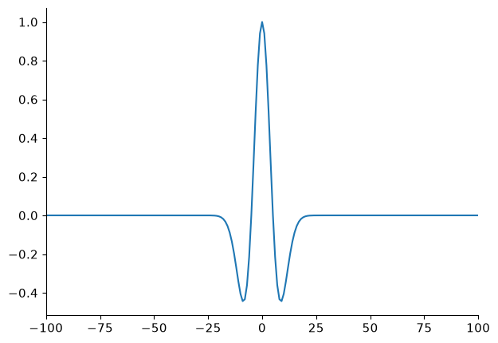

```python
plt.rcParams["figure.figsize"] = (7, 5)
plot(t, h)
xlim(-100, 100)
```

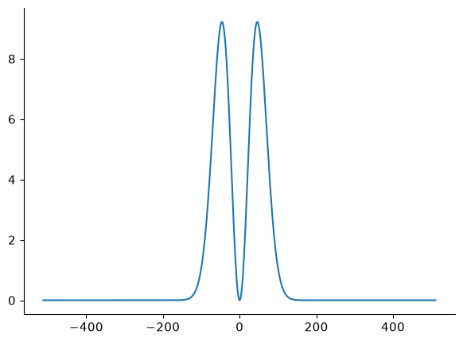

```python
plot(t, fft.fftshift(abs(h_tf)))
```

We generate a synthetic sparse signal $x^\sharp$, with only a small number of nonzero coefficients.

```python
random.seed(
    80
)  # we set the seed of the random number generator for reproducibility purpose.
```

```python
s = round(N * 0.01)  # number of nonzero elements of xsharp
sel = random.permutation(N)
sel = sel[0:s]  # indices of the nonzero elements of xsharp
xsharp = zeros(N)
xsharp[sel] = sign(randn(s)) * (1 - 0.3 * rand(s))
```

```python
noiselevel = 0.2
```

Compute the measurements $y=A x^\sharp + w$ where $w$ is a realization of white Gaussian noise.

```python
y = opA(xsharp) + noiselevel * randn(N)
```

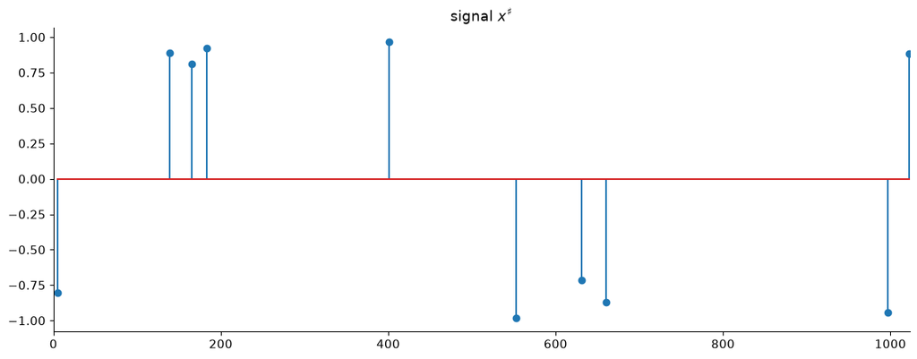

```python
plt.rcParams["figure.figsize"] = (14, 5)
stem(sel, xsharp[sel])
xlim(0, N - 1)
title(r"signal $x^\sharp$")
```

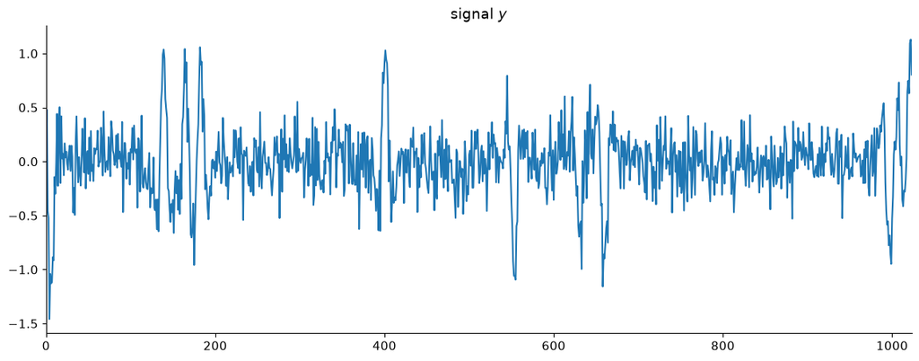

```python
plt.rcParams["figure.figsize"] = (14, 5)
plot(range(N), y)
xlim(0, N - 1)
title("signal $y$")
```

## Deconvolution

We now implement the foward-backward algorithm to recover an estimate of the sparse signal

We define the regularization parameter $\la$.

```python
Lambda = 3
```

We define the proximity operator of $\ga g$.

```python
def prox_gamma_g(x, gamma, Lambda):
    return x - x / maximum(abs(x) / (Lambda * gamma), 1)  # soft-thresholding
```

We define the gradient operator of $f$. Note that $A^*=A$ because the filter $h$ is symmetric.

**Worked example**

The implementation below computes the function grad_f.

```python
grad_f = lambda x: real(fft.ifft(fft.fft(opA(x) - y) * h_tf.conj()))
```

We define the Lipschitz constant $\beta$ of $\nabla f$.

```python
beta = abs(fft.fft(h)).max() ** 2
beta
```

```
np.float64(85.03218404550675)
```

We define the stepsize $\ga$, which must be smaller than $2/\beta$.

```python
gamma = 1.9 / beta
```

We compute the solution of $\ell_1$ deconvolution (basis pursuit denoising). We keep track of the energy $E_k=f(x^{(k)})+g(x^{(k)})$.

**Worked example**

The implementation below computes the forward-backward iteration.

```python
nbiter = 2000
x = y
En_array = zeros(nbiter + 1)
En_array[0] = norm(opA(x) - y) ** 2 / 2 + Lambda * norm(x, ord=1)
for iter in range(nbiter):  # iter goes from 0 to nbiter-1
    x = prox_gamma_g(x - gamma * grad_f(x), gamma, Lambda)
    En_array[iter + 1] = norm(opA(x) - y) ** 2 / 2 + Lambda * norm(x, ord=1)
x_restored = x
```

We display the result.

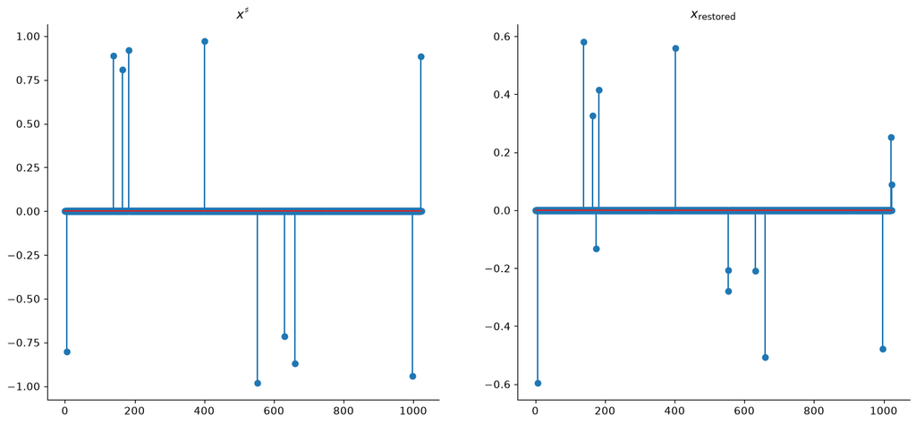

```python
fig, (subfig1, subfig2) = subplots(
    1, 2, figsize=(16, 7)
)  # one figure with two horizontal subfigures
subfig1.stem(xsharp)
subfig2.stem(x_restored)
subfig1.set_title(r"$x^\sharp$")
subfig2.set_title(r"$x_\mathrm{restored}$")
```

We plot the relative error $(E_k-E^\star)/(E_0-E^\star)$ in log-scale with respect to $k$.

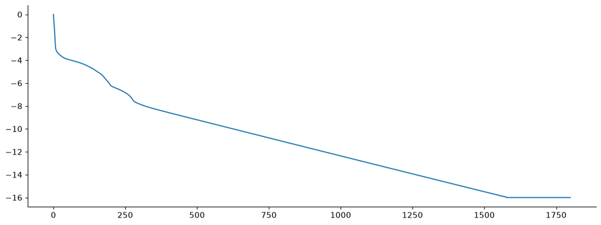

```python
plot(
    log10(
        np.maximum(
            (En_array[0:1800] - En_array[-1]) / (En_array[0] - En_array[-1]), 1e-16
        )
    )
)
```

## Over-relaxed Forward-Backward

Let us assume $\gamma=1/\beta$. Convergence of the iterates $x^{(k)}$ and $z^{(k)}$ to a solution is guaranteed for $ 0 < \rho < 1/2 $. The weaker property of convergence of $ E(x^{(k)}) $ to $E^\star$ is proved, when $ 1/2\leq \rho <1 $.

**Worked example**

The implementation below computes the over-relaxed forward-backward iteration.

```python
gamma = 1 / beta
nbiter = 1700
rho = 0.95
x = y
En_array_overrelaxed = zeros(nbiter + 1)
En_array_overrelaxed[0] = norm(opA(x) - y) ** 2 / 2 + Lambda * norm(x, ord=1)
for iter in range(nbiter):
    x = x + rho * (prox_gamma_g(x - gamma * grad_f(x), gamma, Lambda) - x)
    En_array_overrelaxed[iter + 1] = norm(opA(x) - y) ** 2 / 2 + Lambda * norm(x, ord=1)
```

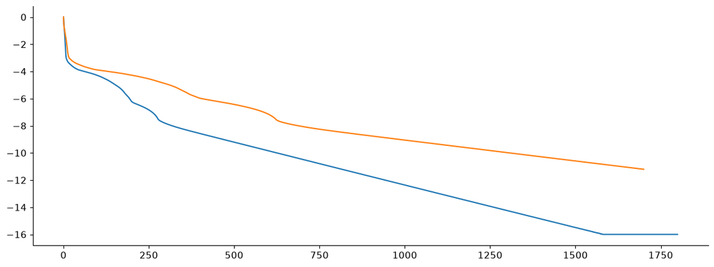

```python
plot(
    log10(
        np.maximum(
            (En_array[0:1800] - En_array[-1]) / (En_array[0] - En_array[-1]), 1e-16
        )
    )
)
plot(
    log10(
        np.maximum(
            (En_array_overrelaxed[0:1800] - En_array[-1])
            / (En_array[0] - En_array[-1]),
            1e-16,
        )
    )
)
```

As we see, in this example, over-relaxation does not bring any speedup, because $\gamma$ is lower than without over-relaxation. There are other setting parameters or other problems, for which over-relaxation does bring a significant speedup.

## FISTA-like Accelerated Forward-Backward Algorithm

We consider the FISTA algorithm introduced in:

A. Beck and M. Teboulle, "A Fast Iterative Shrinkage-Thresholding Algorithm for Linear Inverse Problems", *SIAM Journal on Imaging Sciences*, 2009.

More precisely, we consider a slightly modified version of FISTA, whose convergence is proved, see A. Chambolle and C. Dossal, "On the convergence of the iterates of "FISTA"", preprint, 2015.

Given an initial estimate $x^{(0)}$ of the solution and a parameter $a>2$, the algorithm sets $\gamma=1/\beta$, sets $z^{(0)}=x^{(0)} \in \RR^N$, and iterates, for $k=1,2,\ldots$ $$ x^{(k)} = \text{prox}_{\ga g}\pa{ z^{(k-1)} - \ga \nabla f( z^{(k-1)} ) }. $$ $$ \alpha_k=(k-1)/(k+a) $$ $$ z^{(k)} = x^{(k)} + \alpha_k \pa{ x^{(k)} - x^{(k-1)} } $$

It is proved that the iterates $x^{(k)}$ converge to a solution $x^\star$ of the problem. Moreover, the optimal convergence rate for this class of problems is reached, namely $$ E_k - E^\star = O(1/k^2), $$ whereas the convergence rate for the normal forward-backward is only $O(1/k)$.

Note the difference between the over-relaxed forward-backward and the accelerated forward-backward: the later is based on an inertia mechanism, of different nature than over-relaxation.

**Worked example**

The implementation below computes the accelerated forward-backward iteration.

```python
gamma = 1 / beta
nbiter = 1700
a = 10
x = y
En_array_fista = zeros(nbiter + 1)
En_array_fista[0] = norm(opA(x) - y) ** 2 / 2 + Lambda * norm(x, ord=1)
z = x.copy()
for iter in range(nbiter):
    x_old = x.copy()
    x = prox_gamma_g(z - gamma * grad_f(z), gamma, Lambda)
    z = x + iter / (iter + a) * (x - x_old)
    En_array_fista[iter + 1] = norm(opA(x) - y) ** 2 / 2 + Lambda * norm(x, ord=1)
```

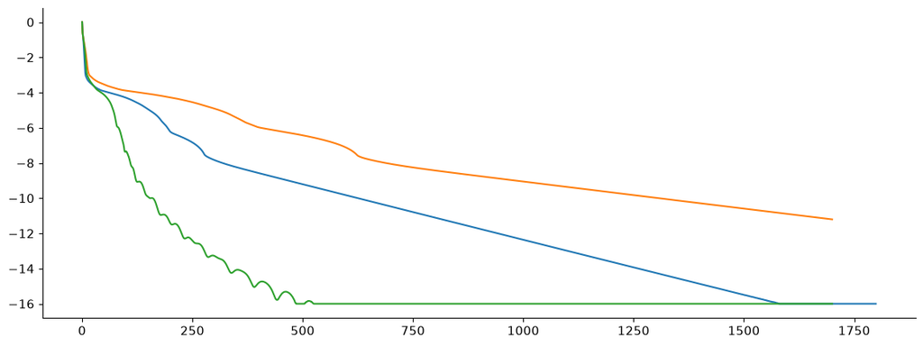

```python
plot(
    log10(
        np.maximum(
            (En_array[0:1800] - En_array[-1]) / (En_array[0] - En_array[-1]), 1e-16
        )
    )
)
plot(
    log10(
        np.maximum(
            (En_array_overrelaxed[0:1800] - En_array[-1])
            / (En_array[0] - En_array[-1]),
            1e-16,
        )
    )
)
plot(
    log10(
        np.maximum(
            (En_array_fista[0:1800] - En_array[-1]) / (En_array[0] - En_array[-1]),
            1e-16,
        )
    )
)
```

**Worked example**

Try different values of a. You can try a=3,10,30,50,100.

We can note that the accelerated forward-backward is not monotonic: the cost function E is not decreasing along with the iterations and some oscillations are present.

## References and further reading

- Stephen Boyd and Lieven Vandenberghe. [Convex Optimization](https://web.stanford.edu/~boyd/cvxbook/). 2004, Cambridge University Press. Convexity, duality, optimality conditions, and interior-point methods.
- Neal Parikh and Stephen Boyd. [Proximal Algorithms](https://web.stanford.edu/~boyd/papers/prox_algs.html). 2014, Foundations and Trends in Optimization 1(3), 127–239. Proximity operators and splitting methods for nonsmooth objectives.
- Amir Beck and Marc Teboulle. [A Fast Iterative Shrinkage-Thresholding Algorithm for Linear Inverse Problems](https://doi.org/10.1137/080716542). 2009, SIAM Journal on Imaging Sciences 2(1), 183–202. Accelerated proximal gradient descent and its convergence rate.
- Antonin Chambolle and Thomas Pock. [A First-Order Primal-Dual Algorithm for Convex Problems with Applications to Imaging](https://doi.org/10.1007/s10851-010-0251-1). 2011, Journal of Mathematical Imaging and Vision 40, 120–145. Primal–dual splitting for total variation and other composite penalties.
- Laurent Condat. [A Primal–Dual Splitting Method for Convex Optimization Involving Lipschitzian, Proximable and Linear Composite Terms](https://doi.org/10.1007/s10957-012-0245-9). 2013, Journal of Optimization Theory and Applications 158, 460–479. Step-size conditions and a general primal–dual framework.